# Recovering the 2020 COVID Unemployment Spike in St. Louis City

A TWDeConv Example: Deconvolving ACS 5-Year Unemployment Rate Estimates at the Census Tract Level

TWDeConv Example

2026-03-05

# 1 Background

The ACS 5-year unemployment rate for Census tract $i$ ending in year $s$ is approximately:

$$U_{i,s} = \frac{1}{5}\sum_{t=s-4}^{s}
X_{i,t} + \varepsilon_{i,s}$$

where $X_{i,t}$ is the **true annual** unemployment rate — never directly observable at the tract level. **TWDeConv** recovers $X$ by solving a Kronecker-structured spatio-temporal generalised lasso via ADMM.

COVID-19 caused the national unemployment rate to spike from roughly 3.5% in early 2020 to nearly 15% in April 2020, then recover through 2021–2022. This is the sharpest short-term labour market shock in post-WWII US history. Three widely-used ACS 5-year products each tell a *different* story about “unemployment around 2020”:

| Window | Years covered | What it shows |
| --- | --- | --- |
| ACS 2016–2020 | 2016–2020 | Blends 4 pre-COVID years with 1 spike year |
| ACS 2017–2021 | 2017–2021 | Spike mixed with one recovery year |
| ACS 2018–2022 | 2018–2022 | Spike diluted by two full recovery years |

**A key data gap:** The Census Bureau did *not* release standard ACS 1-year tract-level estimates for 2020. The Bureau released only “experimental” county-and-above estimates with explicit quality caveats. This means tract-level annual unemployment for 2020 does not exist in any standard Census product — precisely the gap TWDeConv fills.

We use two ACS variables:

| ACS Variable | Description |
| --- | --- |
| `B23025_003` | Civilian labour force (denominator) |
| `B23025_005` | Unemployed civilians (numerator) |

The unemployment rate = `B23025_005` / `B23025_003` is a proportion on $[0,1]$, so the same ACS ratio SE formula used in the Chicago racial composition example applies directly.

St. Louis City is an **independent city** in Missouri (county FIPS `510`), separate from St. Louis County, with ~100 Census tracts and historically marked spatial inequality between North and South city neighbourhoods — making it an ideal study region for detecting spatial heterogeneity in COVID unemployment.

# 2 Setup

```r
devtools::install_github("YungChun0303/TWDeConv")
packageVersion("TWDeConv")
```

```
## [1] '0.1.1'
```

```r
library(TWDeConv)
library(ggplot2)
library(patchwork)
library(sf)
library(Matrix)

options(tigris_use_cache = TRUE)
```

> **Census API key required.** Register at https://api.census.gov/data/key_signup.html and install once with:

> ```r
> tidycensus::census_api_key("YOUR_KEY_HERE", install = TRUE)
> ```

# 3 Fetch and Prepare ACS Data

We use five consecutive ACS 5-year windows (end years 2018–2022):

- $S = 5$ observed windows
- $T = S + 4 = 9$ latent annual time points (2014–2022)

Including the window ending in 2020 (covering 2016–2020) means the model has direct information about the pandemic year at the tract level.

## 3.1 Step 1: Structural matrices from unemployed count

`prep_acs_for_deconv()` is called with `B23025_005` (unemployed count) to obtain the structural matrices ($M$, $D$, $L_s$) and the aligned GEOID set. We will replace $Y$ and $W$ with rate-based counterparts in Step 3.

```r
year_ends <- 2018:2022
S         <- length(year_ends)

inp_unemp <- prep_acs_for_deconv(
  state     = "MO",
  county    = "510",
  year_ends = year_ends,
  variables = c(unemp = "B23025_005"),
  k         = 2L,
  queen     = TRUE,
  vre       = TRUE,
  cache_dir = "~/acs_cache"
)
print(inp_unemp)
```

```
## ── DeconvInput (TWDeConv) ─────────────────────────────────
##   Geography : tract  |  510 county, MO
##   Variable  : unemp  (code: B23025_005)
##   Windows   : 5  (ACS end years 2018 – 2022)
##   Latent yrs: 9  (2014 – 2022)
##   Units (n) : 102
##   Y dims    : 102 × 5  (units × windows)
##   M dims    : 5 × 9  (windows × latent years)
##   W dims    : 510 × 510  (diagonal precision)
##   D dims    : 7 × 9  (order-2 temporal diff)
##   Ls dims   : 102 × 102  (spatial Laplacian)
##   SE source : moe
##
##   Pass to solver:
##     solver <- ADMMSolver$new(
##       Y=inp$Y, M=inp$M, W=inp$W, D=inp$D, Ls=inp$Ls,
##       lambda_t=..., lambda_s=..., rho=1, ridge=1e-4
##     )
## ────────────────────────────────────────────────────────────
```

```r
common_geoids <- rownames(inp_unemp$Y)
n_tracts      <- length(common_geoids)
cat("Common tracts across all windows:", n_tracts, "\n")
```

```
## Common tracts across all windows: 102
```

```r
cat("Latent years:",
    inp_unemp$metadata$first_latent_year, "to",
    inp_unemp$metadata$last_latent_year, "\n")
```

```
## Latent years: 2014 to 2022
```

## 3.2 Step 2: Fetch civilian labour force (denominator)

```r
clf_list <- vector("list", S)
for (i in seq_len(S)) {
  clf_list[[i]] <- fetch_acs_vre_data(
    state     = "MO",
    county    = "510",
    year_end  = year_ends[i],
    variables = c(clf = "B23025_003"),
    geometry  = FALSE,
    vre       = FALSE,
    cache_dir = "~/acs_cache",
    quiet     = TRUE
  )
}
```

## 3.3 Step 3: Compute unemployment rate Y and precision weights W

```r
# -- Unemployed counts and their SEs (n x S) --------------------------------
Y_unemp  <- inp_unemp$Y
SE_unemp <- matrix(
  sqrt(1 / Matrix::diag(inp_unemp$W)),
  nrow = n_tracts, ncol = S,
  dimnames = list(common_geoids, colnames(Y_unemp))
)

# -- Civilian labour force and its SE (n x S), aligned to common_geoids -----
clf_mat    <- matrix(NA_real_, nrow = n_tracts, ncol = S,
                     dimnames = list(common_geoids, colnames(Y_unemp)))
SE_clf_mat <- clf_mat

for (i in seq_len(S)) {
  g_i <- rownames(clf_list[[i]]$estimates)
  idx <- match(common_geoids, g_i)
  clf_mat[, i]    <- clf_list[[i]]$estimates[idx, "clf"]
  SE_clf_mat[, i] <- clf_list[[i]]$se[idx, "clf"]
}

# -- Unemployment rate: U = Unemployed / CLF --------------------------------
Y_prop <- Y_unemp / clf_mat

# -- SE of proportion (ACS ratio formula) -----------------------------------
SE_prop <- matrix(NA_real_, nrow = n_tracts, ncol = S,
                  dimnames = dimnames(Y_prop))

for (i in seq_len(S)) {
  N    <- clf_mat[, i]
  p    <- Y_prop[, i]
  se_x <- SE_unemp[, i]
  se_n <- SE_clf_mat[, i]

  disc         <- se_x^2 - p^2 * se_n^2
  SE_prop[, i] <- ifelse(
    !is.na(disc) & disc >= 0,
    sqrt(disc)                      / N,   # standard ACS ratio formula
    sqrt(se_x^2 + p^2 * se_n^2)    / N    # fallback (sum form)
  )
}

# Guard: zero CLF → NA
SE_prop[is.na(clf_mat) | clf_mat == 0] <- NA_real_
Y_prop[is.na(clf_mat)  | clf_mat == 0] <- NA_real_

cat("Y_prop range  :", round(range(Y_prop,  na.rm = TRUE), 3), "\n")
```

```
## Y_prop range  : 0 0.333
```

```r
cat("SE_prop range :", round(range(SE_prop, na.rm = TRUE), 5), "\n")
```

```
## SE_prop range : 0.00102 0.24658
```

```r
# Precision weight matrix (NA → W = 0, down-weighted from WLS)
W_prop <- build_precision_weights(SE_prop)
cat("W diagonal range:", round(range(Matrix::diag(W_prop)), 1), "\n")
```

```
## W diagonal range: 16.4 961431
```

# 4 Solve the Deconvolution

Unemployment rates live on $[0, 1]$, so we use $\lambda_t = 1$ and $\lambda_s = 0.1$ — the same scale as the Chicago racial composition example. With ~100 St. Louis City tracts the Cholesky factorisation takes seconds.

```r
X_hat <- solve_deconv(
  Y        = Y_prop,
  M        = inp_unemp$M,
  W        = W_prop,
  D        = inp_unemp$D,
  Ls       = inp_unemp$Ls,
  lambda_t = 1,
  lambda_s = 0.1,
  rho      = 1.0,
  max_iter = 5000,
  verbose  = TRUE
)
```

```
##   [ADMM    1]  r_pri=3.430e+00  r_dual=5.841e+01   eps_pri=1.371e-02  eps_dual=2.204e-02
##   [ADMM  100]  r_pri=5.787e-02  r_dual=3.223e-01   eps_pri=1.650e-02  eps_dual=4.129e-02
##   [ADMM  200]  r_pri=1.942e-02  r_dual=9.577e-02   eps_pri=1.650e-02  eps_dual=4.132e-02
##   Converged at iteration 274.
```

```r
# Clip to [0, 1]
X_hat <- pmax(pmin(X_hat, 1), 0)

cat("Recovered dimensions:", nrow(X_hat), "tracts x", ncol(X_hat), "years\n")
```

```
## Recovered dimensions: 102 tracts x 9 years
```

```r
cat("X_hat range:", round(range(X_hat, na.rm = TRUE), 3), "\n")
```

```
## X_hat range: 0 0.478
```

```r
cat("Latent years:",
    inp_unemp$metadata$first_latent_year, "\u2013",
    inp_unemp$metadata$last_latent_year, "\n")
```

```
## Latent years: 2014 – 2022
```

## 4.1 Convergence diagnostic

```r
solver <- solve_deconv(
  Y             = Y_prop,
  M             = inp_unemp$M,
  W             = W_prop,
  D             = inp_unemp$D,
  Ls            = inp_unemp$Ls,
  lambda_t      = 1,
  lambda_s      = 0.1,
  rho           = 1.0,
  max_iter      = 5000,
  return_solver = TRUE
)
solver$print()
```

```
## ── ADMMSolver (TWDeConv) ──────────────────────────────────
##   Problem  : 102 cells × 9 latent years | 5 observed periods
##   Params   : λ_t=1  λ_s=0.1  ρ=1  ridge=1e-08
##   Setup    : done
##   Iters    : 274  |  Converged: TRUE
##   Final    : r_primal=1.287e-02  r_dual=4.073e-02
##   Objective: total=53.75  (data=14.44  temp=14.97  spat=24.34)
## ────────────────────────────────────────────────────────────
```

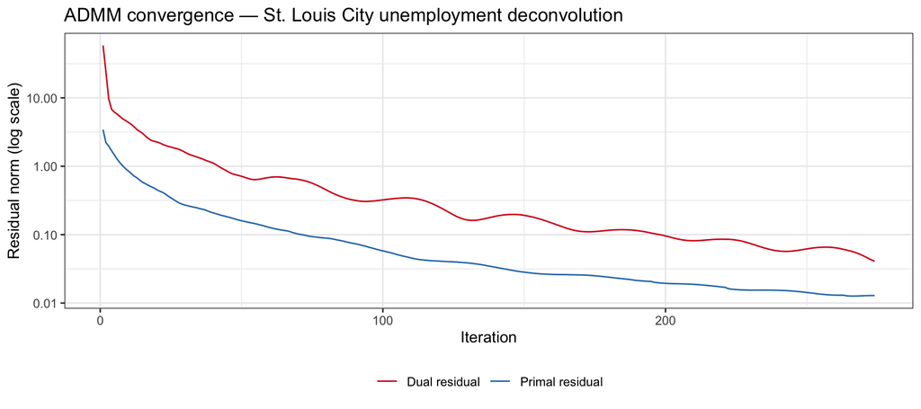

```r
ggplot(solver$history, aes(x = iter)) +
  geom_line(aes(y = r_primal, colour = "Primal residual")) +
  geom_line(aes(y = r_dual,   colour = "Dual residual")) +
  scale_y_log10() +
  scale_colour_manual(
    values = c("Primal residual" = "#2c7bb6", "Dual residual" = "#d7191c"),
    name   = NULL
  ) +
  labs(title = "ADMM convergence \u2014 St. Louis City unemployment deconvolution",
       x = "Iteration", y = "Residual norm (log scale)") +
  theme_bw() +
  theme(legend.position = "bottom")
```

# 5 Results

## 5.1 Long-format data frame

```r
latent_years <- inp_unemp$metadata$first_latent_year:inp_unemp$metadata$last_latent_year

X_long <- as.data.frame(X_hat)
colnames(X_long) <- as.character(latent_years)
X_long$GEOID     <- rownames(X_hat)

X_long <- tidyr::pivot_longer(
  X_long,
  cols      = -GEOID,
  names_to  = "year",
  values_to = "unemp_hat"
)
X_long$year <- as.integer(X_long$year)

Y_long <- as.data.frame(Y_prop)
colnames(Y_long) <- as.character(year_ends)
Y_long$GEOID     <- rownames(Y_prop)

Y_long <- tidyr::pivot_longer(
  Y_long,
  cols      = -GEOID,
  names_to  = "year_end",
  values_to = "unemp_obs"
)
Y_long$year_end <- as.integer(Y_long$year_end)
```

## 5.2 Time series: the 2020 spike in selected tracts

We select five tracts spanning the cross-sectional distribution of 2020 deconvolved unemployment and overlay the observed 5-year windows (thick horizontal segments) against the recovered annual signal (thin lines).

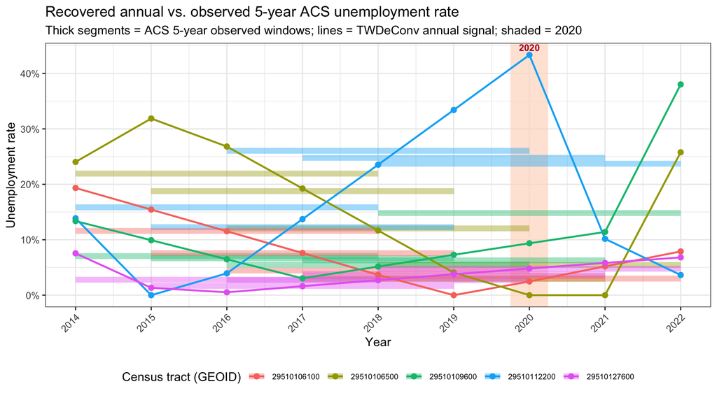

```r
# Select 5 tracts spanning the 2020 recovered unemployment distribution
hat_2020   <- X_hat[, which(latent_years == 2020)]
sel_geoids <- names(sort(hat_2020))[
  round(seq(1, sum(!is.na(hat_2020)), length.out = 5))
]

X_sel <- X_long[X_long$GEOID %in% sel_geoids, ]
Y_sel <- Y_long[Y_long$GEOID %in% sel_geoids, ]

ggplot() +
  annotate("rect",
           xmin = 2019.75, xmax = 2020.25,
           ymin = -Inf, ymax = Inf,
           fill = "#fddbc7", alpha = 0.7) +
  geom_segment(
    data = Y_sel,
    aes(x = year_end - 4, xend = year_end,
        y = unemp_obs, yend = unemp_obs, colour = GEOID),
    linewidth = 2.5, alpha = 0.4
  ) +
  geom_line(
    data = X_sel,
    aes(x = year, y = unemp_hat, colour = GEOID),
    linewidth = 0.8
  ) +
  geom_point(
    data = X_sel,
    aes(x = year, y = unemp_hat, colour = GEOID),
    size = 2
  ) +
  scale_y_continuous(labels = scales::percent_format(accuracy = 1)) +
  scale_x_continuous(breaks = latent_years) +
  annotate("text",
           x = 2020, y = max(X_sel$unemp_hat, na.rm = TRUE),
           label = "COVID\n2020", size = 3, colour = "#b2182b",
           fontface = "bold", vjust = -0.2, hjust = 0.5) +
  labs(
    title    = "Recovered annual vs. observed 5-year ACS unemployment rate",
    subtitle = "Thick segments = ACS 5-year observed windows; lines = TWDeConv annual signal; shaded = 2020",
    x = "Year", y = "Unemployment rate",
    colour = "Census tract (GEOID)"
  ) +
  theme_bw() +
  theme(legend.position = "bottom",
        axis.text.x     = element_text(angle = 45, hjust = 1),
        legend.text     = element_text(size = 7))
```

## 5.3 Spatial maps: unemployment rate across years

```r
tracts_sf <- tidycensus::get_acs(
  geography = "tract",
  variables = "B23025_003",
  state     = "MO",
  county    = "510",
  year      = 2022,
  survey    = "acs5",
  geometry  = TRUE
) |>
  dplyr::select(GEOID, geometry) |>
  dplyr::distinct(GEOID, .keep_all = TRUE)
```

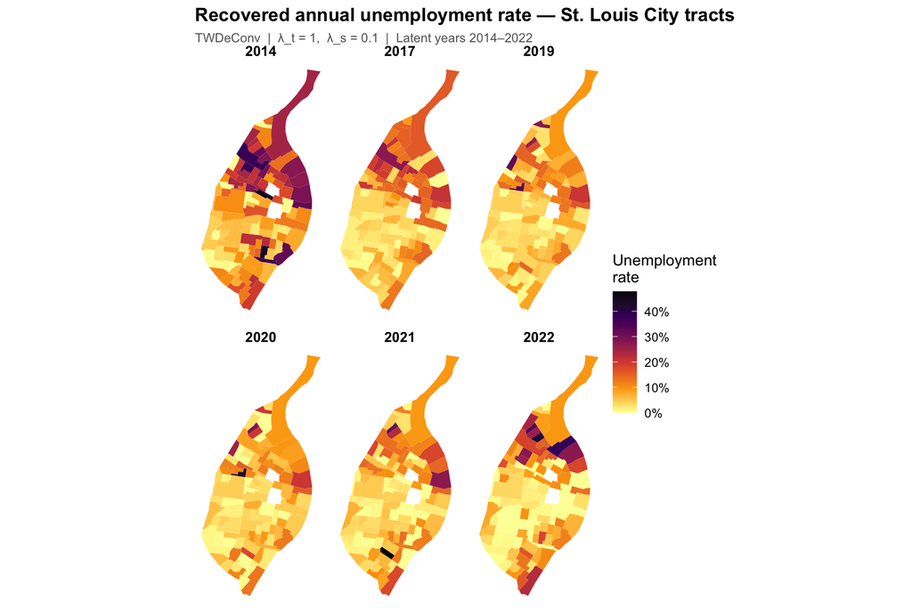

```r
years_to_map <- c(2014, 2017, 2019, 2020, 2021, 2022)

map_panel_df <- X_long |>
  dplyr::filter(year %in% years_to_map) |>
  dplyr::left_join(tracts_sf, by = "GEOID") |>
  sf::st_as_sf()

ggplot(map_panel_df) +
  geom_sf(aes(fill = unemp_hat), colour = NA) +
  facet_wrap(~ year, ncol = 3) +
  scale_fill_viridis_c(
    option   = "inferno", direction = -1,
    name     = "Unemployment\nrate",
    labels   = scales::percent_format(accuracy = 1),
    na.value = "grey80"
  ) +
  labs(
    title    = "Recovered annual unemployment rate \u2014 St. Louis City tracts",
    subtitle = paste0("TWDeConv  |  \u03bb_t = 1,  \u03bb_s = 0.1  |  Latent years ",
                      min(latent_years), "\u2013", max(latent_years))
  ) +
  theme_void() +
  theme(
    strip.text      = element_text(face = "bold", size = 10),
    legend.position = "right",
    plot.title      = element_text(face = "bold"),
    plot.subtitle   = element_text(colour = "grey40", size = 9)
  )
```

# 6 Validation: The 2020 COVID Signal

This section is the core of the example. We compare three estimates of “2020 unemployment” at the tract level:

[output not shown]

Note: No standard Census source exists at the **tract level** for 2020 annual unemployment. The ACS 1-year was suppressed for geographies below 65,000 population that year. TWDeConv provides the only tract-level annual estimate for 2020.

## 6.1 Fetch ACS 2016–2020 window (end year 2020)

```r
unemp_2020_raw <- fetch_acs_vre_data(
  state     = "MO",
  county    = "510",
  year_end  = 2020,
  variables = c(unemp = "B23025_005"),
  geometry  = FALSE,
  vre       = FALSE,
  cache_dir = "~/acs_cache",
  quiet     = TRUE
)

clf_2020_raw <- fetch_acs_vre_data(
  state     = "MO",
  county    = "510",
  year_end  = 2020,
  variables = c(clf = "B23025_003"),
  geometry  = FALSE,
  vre       = FALSE,
  cache_dir = "~/acs_cache",
  quiet     = TRUE
)

g2020 <- intersect(rownames(unemp_2020_raw$estimates),
                   rownames(clf_2020_raw$estimates))

acs_2020w_rate <- unemp_2020_raw$estimates[g2020, "unemp"] /
                  clf_2020_raw$estimates[g2020, "clf"]
names(acs_2020w_rate) <- g2020

cat("ACS 2016-2020 window tracts:", length(g2020), "\n")
```

```
## ACS 2016-2020 window tracts: 104
```

```r
cat("Rate range:", round(range(acs_2020w_rate, na.rm = TRUE), 3), "\n")
```

```
## Rate range: 0 0.261
```

## 6.2 Three-way summary statistics

```r
# Merge all three estimates onto the common tract set
twdeconv_2020_vec <- X_hat[, which(latent_years == 2020)]
acs_2022w_rate    <- Y_prop[, ncol(Y_prop)]   # ACS 2018-2022 already computed

threeway_df <- data.frame(
  GEOID      = common_geoids,
  acs_2020w  = acs_2020w_rate[match(common_geoids, names(acs_2020w_rate))],
  acs_2022w  = acs_2022w_rate,
  tw_2020    = twdeconv_2020_vec,
  stringsAsFactors = FALSE
)

summary_tbl <- data.frame(
  Source = c(
    "ACS 2016\u20132020 (5-year window, diluted)",
    "ACS 2018\u20132022 (5-year window, buried)",
    "TWDeConv 2020 (annual, deconvolved)"
  ),
  `Median (%)` = round(c(
    median(threeway_df$acs_2020w, na.rm = TRUE),
    median(threeway_df$acs_2022w, na.rm = TRUE),
    median(threeway_df$tw_2020,   na.rm = TRUE)
  ) * 100, 1),
  `Mean (%)` = round(c(
    mean(threeway_df$acs_2020w, na.rm = TRUE),
    mean(threeway_df$acs_2022w, na.rm = TRUE),
    mean(threeway_df$tw_2020,   na.rm = TRUE)
  ) * 100, 1),
  `90th pct (%)` = round(c(
    quantile(threeway_df$acs_2020w, 0.9, na.rm = TRUE),
    quantile(threeway_df$acs_2022w, 0.9, na.rm = TRUE),
    quantile(threeway_df$tw_2020,   0.9, na.rm = TRUE)
  ) * 100, 1),
  check.names = FALSE
)

knitr::kable(
  summary_tbl,
  caption = paste0("Tract-level unemployment rate \u2014 three-way comparison",
                   " (St. Louis City, reference year 2020)")
)
```

Tract-level unemployment rate — three-way comparison (St. Louis City, reference year 2020)

| Source | Median (%) | Mean (%) | 90th pct (%) |
| --- | --- | --- | --- |
| ACS 2016–2020 (5-year window, diluted) | 6.1 | 7.6 | 14.7 |
| ACS 2018–2022 (5-year window, buried) | 5.1 | 6.9 | 14.4 |
| TWDeConv 2020 (annual, deconvolved) | 4.8 | 6.7 | 12.8 |

## 6.3 Three-way spatial maps

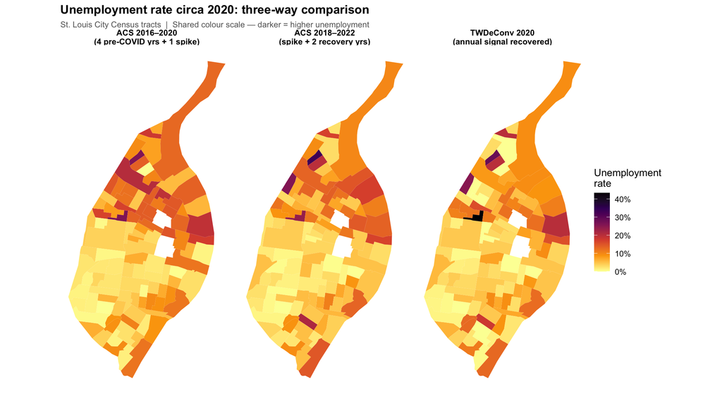

```r
map_threeway_sf <- threeway_df |>
  dplyr::left_join(tracts_sf, by = "GEOID") |>
  sf::st_as_sf() |>
  tidyr::pivot_longer(
    cols      = c(acs_2020w, acs_2022w, tw_2020),
    names_to  = "source",
    values_to = "unemp_rate"
  ) |>
  dplyr::mutate(source = factor(
    dplyr::recode(source,
      acs_2020w = "ACS 2016\u20132020\n(4 pre-COVID yrs + 1 spike)",
      acs_2022w = "ACS 2018\u20132022\n(spike + 2 recovery yrs)",
      tw_2020   = "TWDeConv 2020\n(annual signal recovered)"
    ),
    levels = c(
      "ACS 2016\u20132020\n(4 pre-COVID yrs + 1 spike)",
      "ACS 2018\u20132022\n(spike + 2 recovery yrs)",
      "TWDeConv 2020\n(annual signal recovered)"
    )
  ))

ggplot(map_threeway_sf) +
  geom_sf(aes(fill = unemp_rate), colour = NA) +
  facet_wrap(~ source, nrow = 1) +
  scale_fill_viridis_c(
    option   = "inferno", direction = -1,
    name     = "Unemployment\nrate",
    labels   = scales::percent_format(accuracy = 1),
    na.value = "grey80"
  ) +
  labs(
    title    = "Unemployment rate circa 2020: three-way comparison",
    subtitle = "St. Louis City Census tracts  |  Shared colour scale \u2014 darker = higher unemployment"
  ) +
  theme_void() +
  theme(
    strip.text      = element_text(face = "bold", size = 9),
    legend.position = "right",
    plot.title      = element_text(face = "bold"),
    plot.subtitle   = element_text(colour = "grey40", size = 9)
  )
```

## 6.4 Scatter: ACS windows vs. TWDeConv 2020

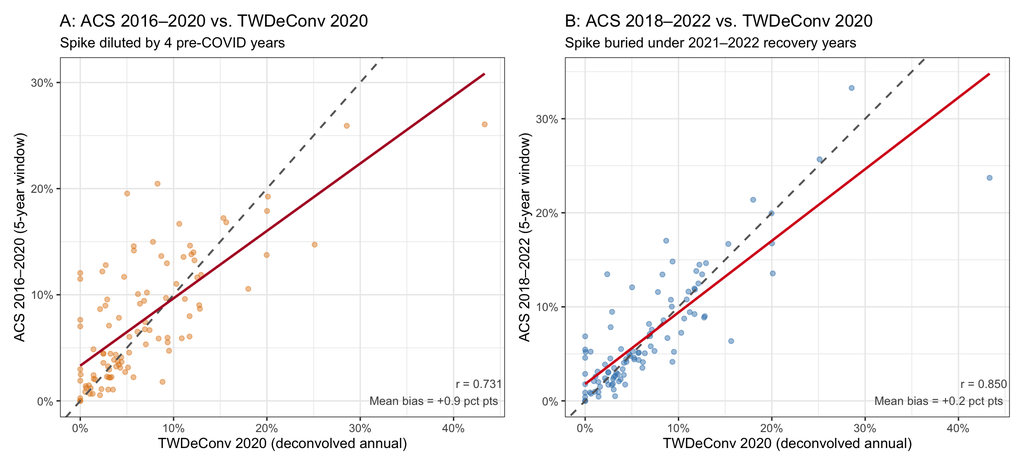

```r
r_2020w    <- cor(threeway_df$tw_2020, threeway_df$acs_2020w, use = "complete.obs")
r_2022w    <- cor(threeway_df$tw_2020, threeway_df$acs_2022w, use = "complete.obs")
bias_2020w <- mean(threeway_df$acs_2020w - threeway_df$tw_2020, na.rm = TRUE)
bias_2022w <- mean(threeway_df$acs_2022w - threeway_df$tw_2020, na.rm = TRUE)

p_vs_2020w <- ggplot(threeway_df,
                     aes(x = tw_2020, y = acs_2020w)) +
  geom_point(alpha = 0.45, size = 1.5, colour = "#e08214") +
  geom_abline(slope = 1, intercept = 0, linetype = "dashed",
              linewidth = 0.7, colour = "grey40") +
  geom_smooth(method = "lm", se = FALSE,
              colour = "#b2182b", linewidth = 0.9) +
  scale_x_continuous(labels = scales::percent_format(accuracy = 1),
                     limits = c(0, NA)) +
  scale_y_continuous(labels = scales::percent_format(accuracy = 1),
                     limits = c(0, NA)) +
  annotate("text", x = Inf, y = -Inf, hjust = 1.05, vjust = -0.5,
           size = 3.2, colour = "grey30",
           label = sprintf("r = %.3f\nMean bias = %+.1f pct pts",
                           r_2020w, bias_2020w * 100)) +
  labs(
    title    = "A: ACS 2016\u20132020 vs. TWDeConv 2020",
    subtitle = "Spike diluted by 4 pre-COVID years",
    x = "TWDeConv 2020 (deconvolved annual)",
    y = "ACS 2016\u20132020 (5-year window)"
  ) +
  theme_bw()

p_vs_2022w <- ggplot(threeway_df,
                     aes(x = tw_2020, y = acs_2022w)) +
  geom_point(alpha = 0.45, size = 1.5, colour = "#2c7bb6") +
  geom_abline(slope = 1, intercept = 0, linetype = "dashed",
              linewidth = 0.7, colour = "grey40") +
  geom_smooth(method = "lm", se = FALSE,
              colour = "#d7191c", linewidth = 0.9) +
  scale_x_continuous(labels = scales::percent_format(accuracy = 1),
                     limits = c(0, NA)) +
  scale_y_continuous(labels = scales::percent_format(accuracy = 1),
                     limits = c(0, NA)) +
  annotate("text", x = Inf, y = -Inf, hjust = 1.05, vjust = -0.5,
           size = 3.2, colour = "grey30",
           label = sprintf("r = %.3f\nMean bias = %+.1f pct pts",
                           r_2022w, bias_2022w * 100)) +
  labs(
    title    = "B: ACS 2018\u20132022 vs. TWDeConv 2020",
    subtitle = "Spike buried under 2021\u20132022 recovery years",
    x = "TWDeConv 2020 (deconvolved annual)",
    y = "ACS 2018\u20132022 (5-year window)"
  ) +
  theme_bw()

patchwork::wrap_plots(p_vs_2020w, p_vs_2022w, nrow = 1)
```

# 7 City-Level Sanity Check

At the city level we can compare the labour-force-weighted mean of TWDeConv tract estimates with the ACS 1-year county-level releases for available years (2015–2019, 2021–2022). The 2020 ACS 1-year experimental estimate is included where accessible, with a clear label noting its quality caveats.

This is an imperfect benchmark — TWDeConv operates at the tract level while ACS 1-year is a city-aggregate survey — but consistent order-of-magnitude agreement confirms the deconvolution is producing plausible annual signals.

```r
acs1_years <- c(2015:2019, 2021:2022)

acs1_list <- setNames(vector("list", length(acs1_years)),
                      as.character(acs1_years))

for (yr in acs1_years) {
  acs1_list[[as.character(yr)]] <- tryCatch({
    tidycensus::get_acs(
      geography = "county",
      variables = c(unemp = "B23025_005", clf = "B23025_003"),
      state     = "MO",
      county    = "510",
      year      = yr,
      survey    = "acs1",
      output    = "wide"
    )
  }, error = function(e) {
    message("ACS 1-year fetch failed for ", yr, ": ", conditionMessage(e))
    NULL
  })
}

# 2020 experimental 1-year
acs1_2020_exp <- tryCatch(
  tidycensus::get_acs(
    geography = "county",
    variables = c(unemp = "B23025_005", clf = "B23025_003"),
    state     = "MO",
    county    = "510",
    year      = 2020,
    survey    = "acs1",
    output    = "wide"
  ),
  error = function(e) {
    message("2020 ACS 1-year experimental fetch failed: ", conditionMessage(e))
    NULL
  }
)

# Build ACS 1-year city-level rate time series
acs1_df <- dplyr::bind_rows(lapply(names(acs1_list), function(yr) {
  d <- acs1_list[[yr]]
  if (is.null(d)) return(NULL)
  data.frame(year         = as.integer(yr),
             unemp_acs1   = d$unempE / d$clfE,
             experimental = FALSE,
             stringsAsFactors = FALSE)
}))

if (!is.null(acs1_2020_exp)) {
  acs1_df <- rbind(acs1_df,
                   data.frame(year         = 2020L,
                              unemp_acs1   = acs1_2020_exp$unempE / acs1_2020_exp$clfE,
                              experimental = TRUE,
                              stringsAsFactors = FALSE))
}

# TWDeConv city-level: labour-force-weighted tract mean (weight = mean CLF)
lf_avg  <- rowMeans(clf_mat, na.rm = TRUE)
tw_city <- sapply(seq_along(latent_years), function(j) {
  weighted.mean(X_hat[, j], w = lf_avg, na.rm = TRUE)
})

tw_city_df <- data.frame(year = latent_years, unemp_city_hat = tw_city)
sanity_df  <- dplyr::left_join(tw_city_df, acs1_df, by = "year")
```

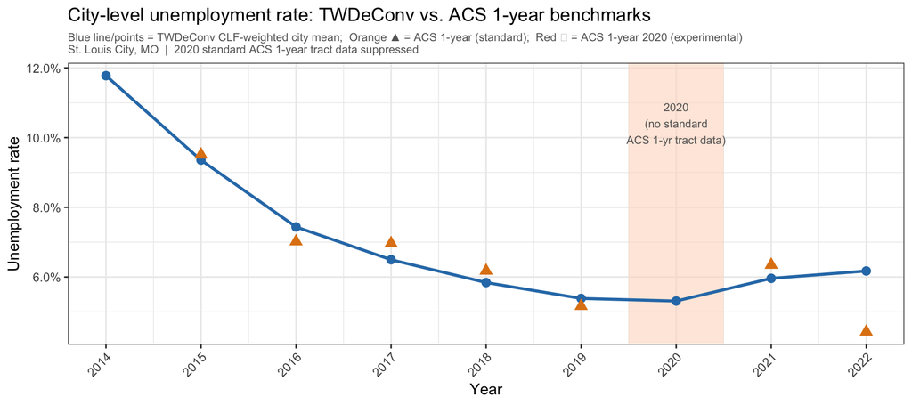

```r
ggplot(sanity_df, aes(x = year)) +
  annotate("rect",
           xmin = 2019.5, xmax = 2020.5, ymin = -Inf, ymax = Inf,
           fill = "#fddbc7", alpha = 0.6) +
  annotate("text",
           x = 2020, y = Inf, vjust = 2, size = 2.8, colour = "grey40",
           label = "2020\n(no standard\nACS 1-yr tract data)") +
  geom_line(aes(y = unemp_city_hat), colour = "#2c7bb6", linewidth = 1) +
  geom_point(aes(y = unemp_city_hat), colour = "#2c7bb6", size = 2.5) +
  {if (nrow(dplyr::filter(sanity_df, !is.na(unemp_acs1), !isTRUE(experimental))) > 0)
    geom_point(data   = dplyr::filter(sanity_df, !is.na(unemp_acs1),
                                      !isTRUE(experimental)),
               aes(y = unemp_acs1),
               colour = "#e08214", size = 3, shape = 17)
  } +
  {if (!is.null(acs1_2020_exp) && nrow(dplyr::filter(sanity_df, isTRUE(experimental))) > 0)
    geom_point(data   = dplyr::filter(sanity_df, isTRUE(experimental)),
               aes(y = unemp_acs1),
               colour = "#d7191c", size = 3.5, shape = 8)
  } +
  scale_y_continuous(labels = scales::percent_format(accuracy = 0.1)) +
  scale_x_continuous(breaks = latent_years) +
  labs(
    title    = "City-level unemployment rate: TWDeConv vs. ACS 1-year benchmarks",
    subtitle = paste0(
      "Blue line/points = TWDeConv CLF-weighted city mean;",
      "  Orange \u25b2 = ACS 1-year (standard);  Red \u2217 = ACS 1-year 2020 (experimental)\n",
      "St. Louis City, MO  |  2020 standard ACS 1-year tract data suppressed"
    ),
    x = "Year", y = "Unemployment rate"
  ) +
  theme_bw() +
  theme(axis.text.x = element_text(angle = 45, hjust = 1),
        plot.subtitle = element_text(size = 8, colour = "grey40"))
```

# 8 Precision: Bootstrap SE and MOE

We quantify uncertainty via a parametric bootstrap, then compare the TWDeConv 2020 margin of error (MOE) against the ACS 2018–2022 single-window MOE at the tract level.

## 8.1 Bootstrap SE

```r
boot <- bootstrap_deconv_se(
  Y          = Y_prop,
  SE_Y       = SE_prop,
  M          = inp_unemp$M,
  W          = W_prop,
  D          = inp_unemp$D,
  Ls         = inp_unemp$Ls,
  lambda_t   = 1,
  lambda_s   = 0.1,
  rho        = 1.0,
  max_iter   = 5000,
  B          = 200L,
  conf_level = 0.90,
  clip       = c(0, 1),
  seed       = 42L,
  verbose    = TRUE
)
print(boot)
```

```
## DeconvBootstrap
##   Dimensions : 102 cells x 9 years
##   Replicates : B = 200
##   Conf level : 90%
##   Median MOE : 0.0753
```

## 8.2 Annual signal with 90% bootstrap CI: selected tracts

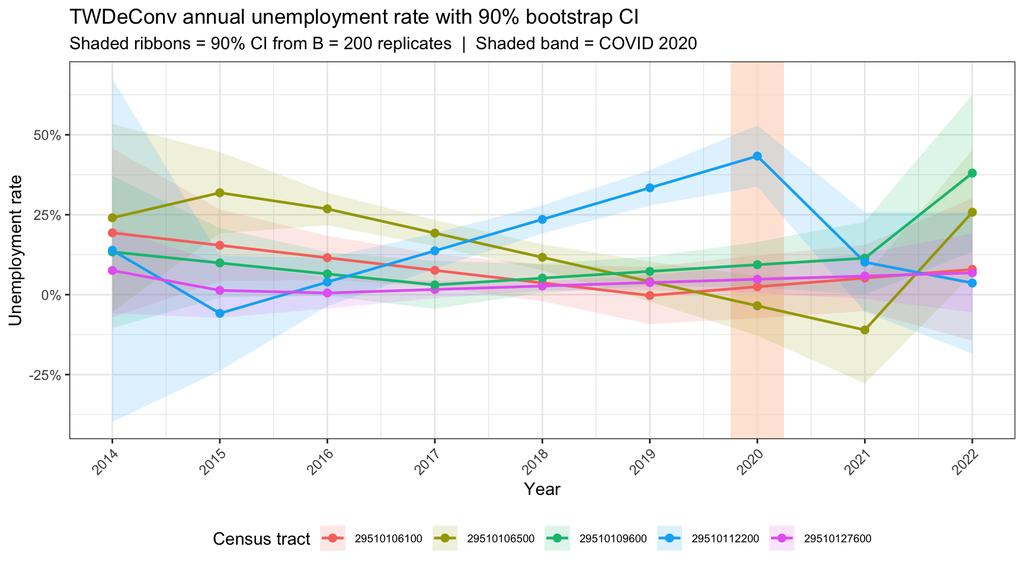

```r
boot_long <- dplyr::bind_rows(lapply(sel_geoids, function(g) {
  i <- which(rownames(boot$X_hat) == g)
  if (length(i) == 0) return(NULL)
  data.frame(
    GEOID    = g,
    year     = latent_years,
    estimate = boot$X_hat[i, ],
    ci_low   = boot$CI_low[i, ],
    ci_high  = boot$CI_high[i, ]
  )
}))

ggplot(boot_long, aes(x = year, colour = GEOID, fill = GEOID)) +
  annotate("rect",
           xmin = 2019.75, xmax = 2020.25, ymin = -Inf, ymax = Inf,
           fill = "#fddbc7", alpha = 0.7) +
  geom_ribbon(aes(ymin = ci_low, ymax = ci_high),
              alpha = 0.15, colour = NA) +
  geom_line(aes(y = estimate), linewidth = 0.8) +
  geom_point(aes(y = estimate), size = 2) +
  scale_y_continuous(labels = scales::percent_format(accuracy = 1)) +
  scale_x_continuous(breaks = latent_years) +
  labs(
    title    = "TWDeConv annual unemployment rate with 90% bootstrap CI",
    subtitle = "Shaded ribbons = 90% CI from B = 200 replicates  |  Shaded band = COVID 2020",
    x = "Year", y = "Unemployment rate",
    colour = "Census tract", fill = "Census tract"
  ) +
  theme_bw() +
  theme(legend.position = "bottom",
        axis.text.x     = element_text(angle = 45, hjust = 1),
        legend.text     = element_text(size = 7))
```

## 8.3 ACS 2018–2022 MOE (single-window baseline)

```r
# SE for the ACS 2018-2022 window is the last column of SE_prop (already computed)
SE_acs22  <- SE_prop[, ncol(SE_prop)]
MOE_acs22 <- 1.645 * SE_acs22    # 90% MOE matching boot$conf_level

cat("ACS 2018-2022 MOE \u2014 median:",
    round(median(MOE_acs22, na.rm = TRUE), 4),
    "  mean:", round(mean(MOE_acs22, na.rm = TRUE), 4), "\n")
```

```
## ACS 2018-2022 MOE — median: 0.0489   mean: 0.0564
```

## 8.4 MOE summary table

```r
moe_2020_col <- which(latent_years == 2020)
moe_tw_2020  <- boot$MOE[, moe_2020_col]

moe_df <- data.frame(
  GEOID   = rownames(boot$MOE),
  moe_tw  = moe_tw_2020,
  moe_acs = MOE_acs22[match(rownames(boot$MOE), common_geoids)],
  stringsAsFactors = FALSE
)
moe_df <- moe_df[!is.na(moe_df$moe_tw) & !is.na(moe_df$moe_acs), ]
moe_df$ratio <- moe_df$moe_tw / moe_df$moe_acs

pct_narrower <- mean(moe_df$ratio < 1, na.rm = TRUE) * 100

summary_moe_tbl <- data.frame(
  Method       = c("TWDeConv 2020 (bootstrap, B = 200)",
                   "ACS 2018\u20132022 (single window)"),
  `Median MOE` = round(c(median(moe_df$moe_tw),  median(moe_df$moe_acs)),  4),
  `Mean MOE`   = round(c(mean(moe_df$moe_tw),    mean(moe_df$moe_acs)),    4),
  `Max MOE`    = round(c(max(moe_df$moe_tw),     max(moe_df$moe_acs)),     4),
  check.names  = FALSE
)

knitr::kable(
  summary_moe_tbl,
  caption = paste0(
    "90% MOE comparison: TWDeConv 2020 vs. ACS 2018\u20132022  |  ",
    round(pct_narrower, 1), "% of tracts have narrower TWDeConv MOE"
  )
)
```

90% MOE comparison: TWDeConv 2020 vs. ACS 2018–2022 | 26.5% of tracts have narrower TWDeConv MOE

| Method | Median MOE | Mean MOE | Max MOE |
| --- | --- | --- | --- |
| TWDeConv 2020 (bootstrap, B = 200) | 0.0603 | 0.0695 | 0.1831 |
| ACS 2018–2022 (single window) | 0.0489 | 0.0564 | 0.2720 |